# Lab 6

### Tune Tree Parameters

1. Create a new specification where you set the learning rate (which you already optimized) and tune the tree parameters.

```r
#specify model new parameters with optimal learn rate
eels_xgb_spec2 <- boost_tree(learn_rate = best_learn_rate,
                             trees = 3000,
                             tree_depth = tune(),
                             min_n = tune(),
                             loss_reduction = tune()
                             ) |>
  set_engine("xgboost") |>
  set_mode("classification")

#put into workflow
eels_wf2 <- workflow() |>
  add_model(eels_xgb_spec2) |>
  add_recipe(eels_rec)
```

2. Set up a tuning grid. This time use grid_max_entropy() to get a representative sampling of the parameter space

```r
#set up parameters to feed to the grid
xgb_params <- parameters( #list same parameters with tune() in spec
  tree_depth(),
  min_n(),
  loss_reduction()
)

#create grid
grid_2 <- grid_max_entropy(
  xgb_params,
  size = 60 #total number of parameter value combos
)

tic() #start timer
#tune in parallel
doParallel::registerDoParallel()
# Fit the workflow on our predefined folds and hyperparameters
fit_eels2 <- eels_wf2 |>
  tune_grid(
    eels_cv,
    grid = grid_2,
    metrics = metric_set(accuracy))
toc() #end timer
```

```
## 1115.98 sec elapsed
```

3. Show the performance of the best models and the estimates for the tree parameter values associated with each.

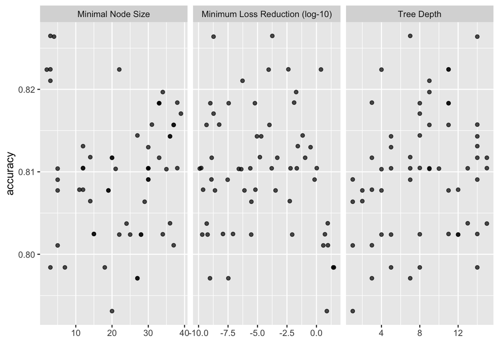

```r
#collect metrics
eels2_metrics <- fit_eels2 |>
  collect_metrics()

#visually check out the accuracy
autoplot(fit_eels2)
```

```r
#YIKES - These are all over the place
#is it becuase of the way the three are combined? Why is there no trend?
```

```r
show_best(fit_eels2) #show me the best tree
```

```
## # A tibble: 5 × 9
##   min_n tree_depth loss_reduction .metric  .estima…¹  mean     n std_err .config
##   <int>      <int>          <dbl> <chr>    <chr>     <dbl> <int>   <dbl> <chr>
## 1     3          7  0.000180      accuracy binary    0.826    10  0.0161 Prepro…
## 2     4         14  0.00000000187 accuracy binary    0.826    10  0.0145 Prepro…
## 3     3         11  0.00414       accuracy binary    0.822    10  0.0173 Prepro…
## 4    22         11  2.42          accuracy binary    0.822    10  0.0163 Prepro…
## 5     2          4  0.0000882     accuracy binary    0.822    10  0.0181 Prepro…
## # … with abbreviated variable name ¹.estimator
```

```r
#store best tuning parameters
best_min_n <- as.numeric(select_best(fit_eels2)[1,1])

best_tree_depth <- as.numeric(select_best(fit_eels2)[1,2])

best_loss <- as.numeric(select_best(fit_eels2)[1,3])
```

### Tune Stochastic Parameters

1. Create a new specification where you set the learning rate and tree parameters (which you already optimized) and tune the stochastic parameters.

```r
#specify model new optimized parameters
eels_xgb_spec3 <- boost_tree(learn_rate = best_learn_rate,
                             trees = 3000,
                             tree_depth = best_tree_depth,
                             min_n = best_min_n,
                             loss_reduction = best_loss,
                             mtry = tune(),
                             sample_size = tune()
                             ) |>
  set_engine("xgboost") |>
  set_mode("classification")

#put into workflow
eels_wf3 <- workflow() |>
  add_model(eels_xgb_spec3) |>
  add_recipe(eels_rec)
```

2. Set up a tuning grid. Use grid_max_entropy() again.

```r
#set up parameters to feed to the grid
xgb_params2 <- parameters( #list same parameters with tune() in spec
  finalize(mtry(), select(baked_eels, -angaus)), #mtry needs to be determined based on data (p)
  sample_size = sample_prop(
    c(0.4, 0.9) #requires proportion rather than integer
  )
)

#create grid
grid_3 <- grid_max_entropy(
  xgb_params2,
 size =  60 #trying larger size to see if this improves
 #larger size improves performance but slower computation
)

tic() #start timer
#tune in parallel
doParallel::registerDoParallel()
# Fit the workflow on our predefined folds and hyperparameters
fit_eels3 <- eels_wf3 |>
  tune_grid(
    eels_cv,
    grid = grid_3,
    metrics = metric_set(accuracy))
toc() #end timer
```

```
## 1321.8 sec elapsed
```

3. Show the performance of the best models and the estimates for the tree parameter values associated with each.

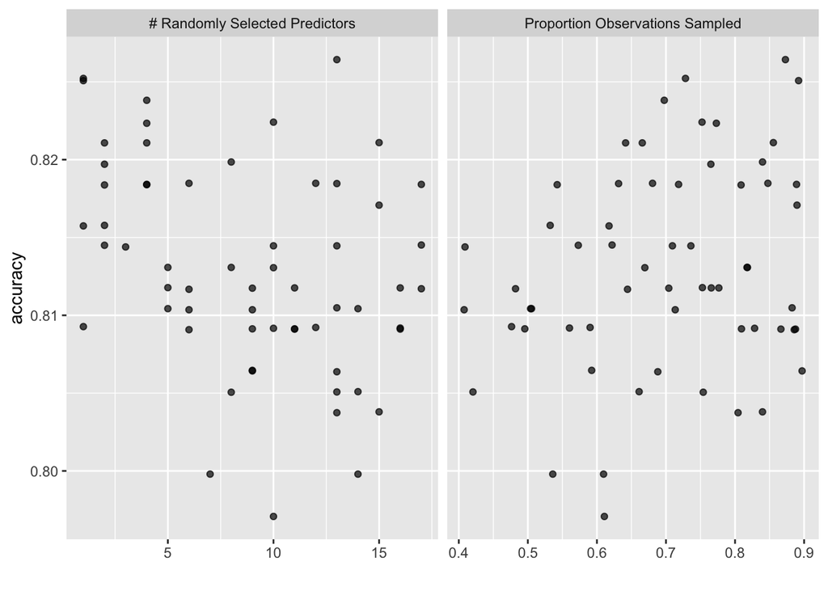

```r
#visually check out the accuracy
autoplot(fit_eels3)
```

```r
show_best(fit_eels3) #show me the best tree
```

```
## # A tibble: 5 × 8
##    mtry sample_size .metric  .estimator  mean     n std_err .config
##   <int>       <dbl> <chr>    <chr>      <dbl> <int>   <dbl> <chr>
## 1    13       0.873 accuracy binary     0.826    10 0.00974 Preprocessor1_Model…
## 2     1       0.728 accuracy binary     0.825    10 0.0166  Preprocessor1_Model…
## 3     1       0.892 accuracy binary     0.825    10 0.0149  Preprocessor1_Model…
## 4     4       0.698 accuracy binary     0.824    10 0.0104  Preprocessor1_Model…
## 5    10       0.752 accuracy binary     0.822    10 0.0142  Preprocessor1_Model…
```

```r
#store best tuning parameters
best_mtry <- as.numeric(select_best(fit_eels3)[1,1])

best_samplesize <- as.numeric(select_best(fit_eels3)[1,2])
```

## Finalize workflow and make final prediction

1. Assemble your final workflow will all of your optimized parameters and do a final fit.

```r
#create final model specification with tuned parameters
eels_final_spec <- boost_tree(
    learn_rate = best_learn_rate,
    trees = 3000,
    tree_depth = best_tree_depth,
    min_n = best_min_n,
    loss_reduction = best_loss,
    mtry = best_mtry,
    sample_size = best_samplesize
) |>
  set_engine("xgboost") |>
  set_mode("classification")

#Final workflow
final_wf <- workflow() |>
  add_model(eels_final_spec) |>
  add_recipe(eels_rec)

#maybe this will work better:
final_model <- finalize_model(eels_final_spec, select_best(fit_eels3))

#Do a final fit and show predictions
final_eels_fit <- last_fit(
  final_model,
  angaus ~.,
  split = eels_split
)

final_eels_fit$.predictions #look at some predictions on the test data
```

```
## [[1]]
## # A tibble: 251 × 6
##    .pred_0  .pred_1  .row .pred_class angaus .config
##      <dbl>    <dbl> <int> <fct>       <fct>  <chr>
##  1  0.925  0.0747       3 0           0      Preprocessor1_Model1
##  2  0.964  0.0363       5 0           1      Preprocessor1_Model1
##  3  0.990  0.00952      6 0           0      Preprocessor1_Model1
##  4  0.730  0.270       24 0           0      Preprocessor1_Model1
##  5  1.00   0.000124    29 0           0      Preprocessor1_Model1
##  6  1.00   0.000443    31 0           0      Preprocessor1_Model1
##  7  0.990  0.00969     37 0           0      Preprocessor1_Model1
##  8  0.445  0.555       42 1           0      Preprocessor1_Model1
##  9  0.700  0.300       45 0           0      Preprocessor1_Model1
## 10  0.0737 0.926       51 1           0      Preprocessor1_Model1
## # … with 241 more rows
## # ℹ Use `print(n = ...)` to see more rows
```

```r
eel_metrics <- collect_metrics(final_eels_fit)

gt::gt(eel_metrics) #print out table of metrics
```

| .metric | .estimator | .estimate | .config |
| --- | --- | --- | --- |
| accuracy | binary | 0.8326693 | Preprocessor1_Model1 |
| roc_auc | binary | 0.8671078 | Preprocessor1_Model1 |

2. How well did your model perform? What types of errors did it make?

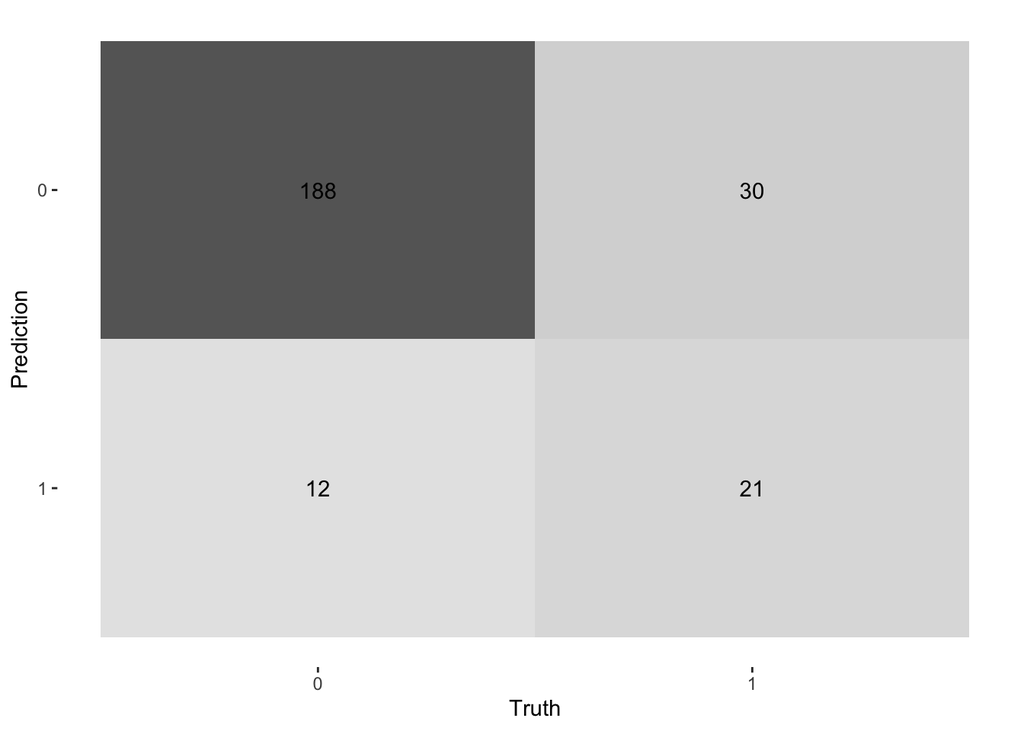

```r
#put predictions into dataframe
eel_preds <- as.data.frame(final_eels_fit$.predictions) |>
  select(c(.pred_class, angaus))

#show the confustion matrix
conf_mat(eel_preds,
         truth = angaus,
         estimate = .pred_class) |>
  autoplot(type = "heatmap")
```